# Risk Factor Analysis

## Outcome Variable

**Outcome Variable:** stunted

## Predictor Variables

**Intervention Variable:** anywast06

**Adjustment Set:**

- arm
- sex
- W_mage
- meducyrs
- W_mhtcm
- month
- brthmon
- delta_W_mage
- delta_meducyrs
- delta_W_mhtcm
- delta_month
- delta_brthmon

## Stratifying Variables

The analysis was stratified on these variable(s):

- agecat
- studyid
- country

## Data Summary

| agecat | studyid | country | anywast06 | stunted | n_cell | n |
| --- | --- | --- | --- | --- | --- | --- |
| Birth | ki0047075b-MAL-ED | BANGLADESH | 0 | 0 | 163 | 255 |
| Birth | ki0047075b-MAL-ED | BANGLADESH | 0 | 1 | 35 | 255 |
| Birth | ki0047075b-MAL-ED | BANGLADESH | 1 | 0 | 47 | 255 |
| Birth | ki0047075b-MAL-ED | BANGLADESH | 1 | 1 | 10 | 255 |
| 6 months | ki0047075b-MAL-ED | BANGLADESH | 0 | 0 | 151 | 241 |
| 6 months | ki0047075b-MAL-ED | BANGLADESH | 0 | 1 | 33 | 241 |
| 6 months | ki0047075b-MAL-ED | BANGLADESH | 1 | 0 | 45 | 241 |
| 6 months | ki0047075b-MAL-ED | BANGLADESH | 1 | 1 | 12 | 241 |
| 24 months | ki0047075b-MAL-ED | BANGLADESH | 0 | 0 | 85 | 212 |
| 24 months | ki0047075b-MAL-ED | BANGLADESH | 0 | 1 | 78 | 212 |
| 24 months | ki0047075b-MAL-ED | BANGLADESH | 1 | 0 | 29 | 212 |
| 24 months | ki0047075b-MAL-ED | BANGLADESH | 1 | 1 | 20 | 212 |
| Birth | ki0047075b-MAL-ED | BRAZIL | 0 | 0 | 157 | 191 |
| Birth | ki0047075b-MAL-ED | BRAZIL | 0 | 1 | 21 | 191 |
| Birth | ki0047075b-MAL-ED | BRAZIL | 1 | 0 | 13 | 191 |
| Birth | ki0047075b-MAL-ED | BRAZIL | 1 | 1 | 0 | 191 |
| 6 months | ki0047075b-MAL-ED | BRAZIL | 0 | 0 | 189 | 209 |
| 6 months | ki0047075b-MAL-ED | BRAZIL | 0 | 1 | 6 | 209 |
| 6 months | ki0047075b-MAL-ED | BRAZIL | 1 | 0 | 14 | 209 |
| 6 months | ki0047075b-MAL-ED | BRAZIL | 1 | 1 | 0 | 209 |
| 24 months | ki0047075b-MAL-ED | BRAZIL | 0 | 0 | 152 | 169 |
| 24 months | ki0047075b-MAL-ED | BRAZIL | 0 | 1 | 5 | 169 |
| 24 months | ki0047075b-MAL-ED | BRAZIL | 1 | 0 | 11 | 169 |
| 24 months | ki0047075b-MAL-ED | BRAZIL | 1 | 1 | 1 | 169 |
| Birth | ki0047075b-MAL-ED | INDIA | 0 | 0 | 120 | 206 |
| Birth | ki0047075b-MAL-ED | INDIA | 0 | 1 | 24 | 206 |
| Birth | ki0047075b-MAL-ED | INDIA | 1 | 0 | 53 | 206 |
| Birth | ki0047075b-MAL-ED | INDIA | 1 | 1 | 9 | 206 |
| 6 months | ki0047075b-MAL-ED | INDIA | 0 | 0 | 131 | 236 |
| 6 months | ki0047075b-MAL-ED | INDIA | 0 | 1 | 31 | 236 |

[output cut: 162 more lines]

The following strata were considered:

- agecat: 24 months, studyid: ki0047075b-MAL-ED, country: BANGLADESH
- agecat: 24 months, studyid: ki0047075b-MAL-ED, country: BRAZIL
- agecat: 24 months, studyid: ki0047075b-MAL-ED, country: INDIA
- agecat: 24 months, studyid: ki0047075b-MAL-ED, country: NEPAL
- agecat: 24 months, studyid: ki0047075b-MAL-ED, country: PERU
- agecat: 24 months, studyid: ki0047075b-MAL-ED, country: SOUTH AFRICA
- agecat: 24 months, studyid: ki0047075b-MAL-ED, country: TANZANIA, UNITED REPUBLIC OF
- agecat: 24 months, studyid: ki1000108-CMC-V-BCS-2002, country: INDIA
- agecat: 24 months, studyid: ki1000108-IRC, country: INDIA
- agecat: 24 months, studyid: ki1017093b-PROVIDE, country: BANGLADESH
- agecat: 24 months, studyid: ki1066203-TanzaniaChild2, country: TANZANIA, UNITED REPUBLIC OF
- agecat: 24 months, studyid: ki1101329-Keneba, country: GAMBIA
- agecat: 24 months, studyid: ki1113344-GMS-Nepal, country: NEPAL
- agecat: 24 months, studyid: ki1114097-CMIN, country: BANGLADESH
- agecat: 24 months, studyid: ki1114097-CMIN, country: PERU
- agecat: 24 months, studyid: ki1114097-CONTENT, country: PERU
- agecat: 6 months, studyid: ki0047075b-MAL-ED, country: BANGLADESH
- agecat: 6 months, studyid: ki0047075b-MAL-ED, country: BRAZIL
- agecat: 6 months, studyid: ki0047075b-MAL-ED, country: INDIA
- agecat: 6 months, studyid: ki0047075b-MAL-ED, country: NEPAL
- agecat: 6 months, studyid: ki0047075b-MAL-ED, country: PERU
- agecat: 6 months, studyid: ki0047075b-MAL-ED, country: SOUTH AFRICA
- agecat: 6 months, studyid: ki0047075b-MAL-ED, country: TANZANIA, UNITED REPUBLIC OF
- agecat: 6 months, studyid: ki1000108-CMC-V-BCS-2002, country: INDIA
- agecat: 6 months, studyid: ki1000108-IRC, country: INDIA
- agecat: 6 months, studyid: ki1000109-EE, country: PAKISTAN
- agecat: 6 months, studyid: ki1000109-ResPak, country: PAKISTAN
- agecat: 6 months, studyid: ki1017093b-PROVIDE, country: BANGLADESH
- agecat: 6 months, studyid: ki1066203-TanzaniaChild2, country: TANZANIA, UNITED REPUBLIC OF
- agecat: 6 months, studyid: ki1101329-Keneba, country: GAMBIA
- agecat: 6 months, studyid: ki1112895-Guatemala BSC, country: GUATEMALA
- agecat: 6 months, studyid: ki1113344-GMS-Nepal, country: NEPAL
- agecat: 6 months, studyid: ki1114097-CMIN, country: BANGLADESH
- agecat: 6 months, studyid: ki1114097-CMIN, country: PERU
- agecat: 6 months, studyid: ki1114097-CONTENT, country: PERU
- agecat: Birth, studyid: ki0047075b-MAL-ED, country: BANGLADESH
- agecat: Birth, studyid: ki0047075b-MAL-ED, country: BRAZIL
- agecat: Birth, studyid: ki0047075b-MAL-ED, country: INDIA
- agecat: Birth, studyid: ki0047075b-MAL-ED, country: NEPAL
- agecat: Birth, studyid: ki0047075b-MAL-ED, country: PERU
- agecat: Birth, studyid: ki0047075b-MAL-ED, country: SOUTH AFRICA
- agecat: Birth, studyid: ki0047075b-MAL-ED, country: TANZANIA, UNITED REPUBLIC OF
- agecat: Birth, studyid: ki1000108-CMC-V-BCS-2002, country: INDIA
- agecat: Birth, studyid: ki1000108-IRC, country: INDIA
- agecat: Birth, studyid: ki1000109-EE, country: PAKISTAN
- agecat: Birth, studyid: ki1000109-ResPak, country: PAKISTAN
- agecat: Birth, studyid: ki1101329-Keneba, country: GAMBIA
- agecat: Birth, studyid: ki1114097-CMIN, country: BANGLADESH
- agecat: Birth, studyid: ki1114097-CMIN, country: PERU
- agecat: Birth, studyid: ki1114097-CONTENT, country: PERU

### Dropped Strata

Some strata were dropped due to rare outcomes:

- agecat: Birth, studyid: ki0047075b-MAL-ED, country: BRAZIL
- agecat: 6 months, studyid: ki0047075b-MAL-ED, country: BRAZIL
- agecat: 24 months, studyid: ki0047075b-MAL-ED, country: BRAZIL
- agecat: Birth, studyid: ki0047075b-MAL-ED, country: PERU
- agecat: 6 months, studyid: ki0047075b-MAL-ED, country: PERU
- agecat: 24 months, studyid: ki0047075b-MAL-ED, country: PERU
- agecat: 6 months, studyid: ki0047075b-MAL-ED, country: SOUTH AFRICA
- agecat: Birth, studyid: ki0047075b-MAL-ED, country: TANZANIA, UNITED REPUBLIC OF
- agecat: 6 months, studyid: ki0047075b-MAL-ED, country: TANZANIA, UNITED REPUBLIC OF
- agecat: 24 months, studyid: ki0047075b-MAL-ED, country: TANZANIA, UNITED REPUBLIC OF
- agecat: Birth, studyid: ki1000109-EE, country: PAKISTAN
- agecat: Birth, studyid: ki1000109-ResPak, country: PAKISTAN
- agecat: 24 months, studyid: ki1066203-TanzaniaChild2, country: TANZANIA, UNITED REPUBLIC OF
- agecat: 6 months, studyid: ki1112895-Guatemala BSC, country: GUATEMALA
- agecat: Birth, studyid: ki1114097-CMIN, country: BANGLADESH
- agecat: 6 months, studyid: ki1114097-CONTENT, country: PERU
- agecat: 24 months, studyid: ki1114097-CONTENT, country: PERU
- agecat: Birth, studyid: ki1114097-CONTENT, country: PERU

## Methods Detail

We’re interested in the causal parameters $E[Y_a]$ for all values of $a \in \mathcal{A}$. These parameters represent the mean outcome if, possibly contrary to fact, we intervened to set all units to have $A=a$. Under the randomization and positivity assumptions, these are identified by the statistical parameters $\psi_a=E_W[E_{Y|A,W}(Y|A=a,W)]$. In addition, we’re interested in the mean of $Y$, $E[Y]$ under no intervention (the observed mean). We will estimate these parameters by using SuperLearner to fit the relevant likelihood factors – $E_{Y|A,W}(Y|A=a,W)$ and $p(A=a|W)$, and then updating our likelihood fit using a joint TMLE.

For unadjusted analyses ($W=\{\}$), initial likelihoods were estimated using Lrnr_glm to estimate the simple $E(Y|A)$ and Lrnr_mean to estimate $p(A)$. For adjusted analyses, a small library containing Lrnr_glmnet, Lrnr_xgboost, and Lrnr_mean was used.

Having estimated these parameters, we will then use the delta method to estimate relative risks and attributable risks relative to a prespecified baseline level of $A$.

[output not shown]

# Results Detail

## Results Plots

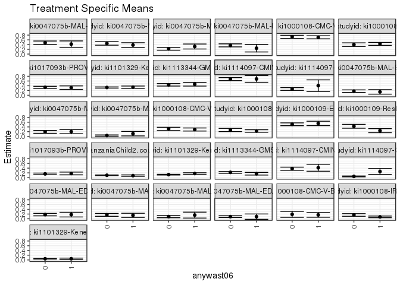

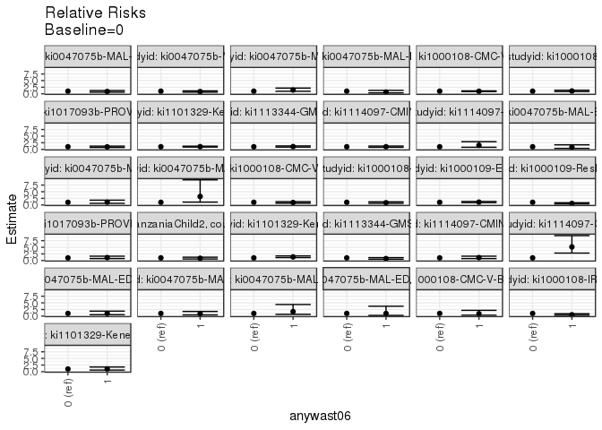

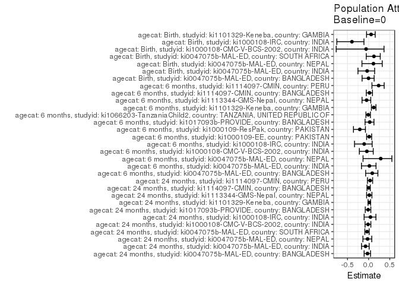

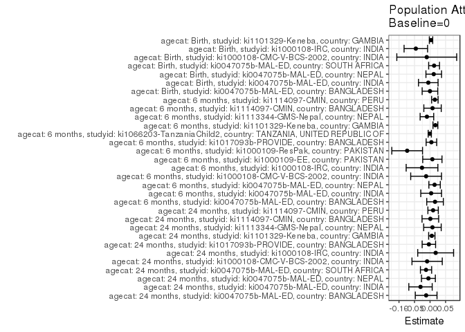

## Results Table

### Parameter: TSM

| agecat | studyid | country | intervention_level | baseline_level | estimate | ci_lower | ci_upper |
| --- | --- | --- | --- | --- | --- | --- | --- |
| Birth | ki0047075b-MAL-ED | BANGLADESH | 0 | NA | 0.1767677 | 0.1235285 | 0.2300069 |
| Birth | ki0047075b-MAL-ED | BANGLADESH | 1 | NA | 0.1754386 | 0.0765063 | 0.2743709 |
| Birth | ki0047075b-MAL-ED | INDIA | 0 | NA | 0.1659170 | 0.1052987 | 0.2265353 |
| Birth | ki0047075b-MAL-ED | INDIA | 1 | NA | 0.1465205 | 0.0603183 | 0.2327226 |
| Birth | ki0047075b-MAL-ED | NEPAL | 0 | NA | 0.0921716 | 0.0443253 | 0.1400179 |
| Birth | ki0047075b-MAL-ED | NEPAL | 1 | NA | 0.1557898 | 0.0309861 | 0.2805935 |
| Birth | ki0047075b-MAL-ED | SOUTH AFRICA | 0 | NA | 0.0904516 | 0.0532849 | 0.1276183 |
| Birth | ki0047075b-MAL-ED | SOUTH AFRICA | 1 | NA | 0.0896580 | -0.0235309 | 0.2028470 |
| Birth | ki1000108-CMC-V-BCS-2002 | INDIA | 0 | NA | 0.1883955 | 0.0608658 | 0.3159253 |
| Birth | ki1000108-CMC-V-BCS-2002 | INDIA | 1 | NA | 0.1642347 | 0.0638293 | 0.2646401 |
| Birth | ki1000108-IRC | INDIA | 0 | NA | 0.1617437 | 0.1066121 | 0.2168752 |
| Birth | ki1000108-IRC | INDIA | 1 | NA | 0.0813369 | 0.0460698 | 0.1166040 |
| Birth | ki1101329-Keneba | GAMBIA | 0 | NA | 0.0500737 | 0.0381447 | 0.0620028 |
| Birth | ki1101329-Keneba | GAMBIA | 1 | NA | 0.0518721 | 0.0271930 | 0.0765511 |
| 6 months | ki0047075b-MAL-ED | BANGLADESH | 0 | NA | 0.1706622 | 0.1156908 | 0.2256336 |
| 6 months | ki0047075b-MAL-ED | BANGLADESH | 1 | NA | 0.1410802 | 0.0456243 | 0.2365360 |
| 6 months | ki0047075b-MAL-ED | INDIA | 0 | NA | 0.1913600 | 0.1310310 | 0.2516889 |
| 6 months | ki0047075b-MAL-ED | INDIA | 1 | NA | 0.2027509 | 0.1133433 | 0.2921584 |
| 6 months | ki0047075b-MAL-ED | NEPAL | 0 | NA | 0.0362786 | 0.0098742 | 0.0626830 |
| 6 months | ki0047075b-MAL-ED | NEPAL | 1 | NA | 0.1161624 | 0.0217297 | 0.2105952 |
| 6 months | ki1000108-CMC-V-BCS-2002 | INDIA | 0 | NA | 0.3159962 | 0.2468477 | 0.3851447 |
| 6 months | ki1000108-CMC-V-BCS-2002 | INDIA | 1 | NA | 0.2917496 | 0.2273852 | 0.3561141 |
| 6 months | ki1000108-IRC | INDIA | 0 | NA | 0.2715745 | 0.2038309 | 0.3393182 |
| 6 months | ki1000108-IRC | INDIA | 1 | NA | 0.2279732 | 0.1751520 | 0.2807944 |
| 6 months | ki1000109-EE | PAKISTAN | 0 | NA | 0.5114034 | 0.4521027 | 0.5707041 |
| 6 months | ki1000109-EE | PAKISTAN | 1 | NA | 0.5482281 | 0.4551046 | 0.6413517 |
| 6 months | ki1000109-ResPak | PAKISTAN | 0 | NA | 0.4268613 | 0.3448940 | 0.5088287 |
| 6 months | ki1000109-ResPak | PAKISTAN | 1 | NA | 0.2426391 | 0.1562801 | 0.3289981 |
| 6 months | ki1017093b-PROVIDE | BANGLADESH | 0 | NA | 0.1569064 | 0.1233900 | 0.1904229 |
| 6 months | ki1017093b-PROVIDE | BANGLADESH | 1 | NA | 0.1747126 | 0.1160792 | 0.2333460 |
| 6 months | ki1066203-TanzaniaChild2 | TANZANIA, UNITED REPUBLIC OF | 0 | NA | 0.0979492 | 0.0840250 | 0.1118733 |
| 6 months | ki1066203-TanzaniaChild2 | TANZANIA, UNITED REPUBLIC OF | 1 | NA | 0.0843906 | 0.0546498 | 0.1141315 |
| 6 months | ki1101329-Keneba | GAMBIA | 0 | NA | 0.1247180 | 0.1091483 | 0.1402877 |
| 6 months | ki1101329-Keneba | GAMBIA | 1 | NA | 0.1718435 | 0.1387722 | 0.2049147 |
| 6 months | ki1113344-GMS-Nepal | NEPAL | 0 | NA | 0.2214418 | 0.1800176 | 0.2628660 |
| 6 months | ki1113344-GMS-Nepal | NEPAL | 1 | NA | 0.1635002 | 0.1069201 | 0.2200803 |
| 6 months | ki1114097-CMIN | BANGLADESH | 0 | NA | 0.3747307 | 0.3078658 | 0.4415955 |
| 6 months | ki1114097-CMIN | BANGLADESH | 1 | NA | 0.4158432 | 0.2682201 | 0.5634662 |
| 6 months | ki1114097-CMIN | PERU | 0 | NA | 0.0499008 | 0.0321778 | 0.0676237 |
| 6 months | ki1114097-CMIN | PERU | 1 | NA | 0.2563844 | 0.1311422 | 0.3816265 |
| 24 months | ki0047075b-MAL-ED | BANGLADESH | 0 | NA | 0.4748445 | 0.3996993 | 0.5499897 |
| 24 months | ki0047075b-MAL-ED | BANGLADESH | 1 | NA | 0.4195882 | 0.2855761 | 0.5536003 |
| 24 months | ki0047075b-MAL-ED | INDIA | 0 | NA | 0.4492337 | 0.3736727 | 0.5247947 |
| 24 months | ki0047075b-MAL-ED | INDIA | 1 | NA | 0.3796845 | 0.2822195 | 0.4771495 |
| 24 months | ki0047075b-MAL-ED | NEPAL | 0 | NA | 0.2202319 | 0.1620889 | 0.2783749 |
| 24 months | ki0047075b-MAL-ED | NEPAL | 1 | NA | 0.3185275 | 0.2131392 | 0.4239159 |
| 24 months | ki0047075b-MAL-ED | SOUTH AFRICA | 0 | NA | 0.3658633 | 0.3019787 | 0.4297479 |
| 24 months | ki0047075b-MAL-ED | SOUTH AFRICA | 1 | NA | 0.2471751 | 0.0877439 | 0.4066063 |
| 24 months | ki1000108-CMC-V-BCS-2002 | INDIA | 0 | NA | 0.7241379 | 0.6576380 | 0.7906378 |
| 24 months | ki1000108-CMC-V-BCS-2002 | INDIA | 1 | NA | 0.7061856 | 0.6420005 | 0.7703706 |
| 24 months | ki1000108-IRC | INDIA | 0 | NA | 0.3975904 | 0.3230503 | 0.4721304 |
| 24 months | ki1000108-IRC | INDIA | 1 | NA | 0.4279835 | 0.3656970 | 0.4902701 |
| 24 months | ki1017093b-PROVIDE | BANGLADESH | 0 | NA | 0.3330938 | 0.2891307 | 0.3770568 |
| 24 months | ki1017093b-PROVIDE | BANGLADESH | 1 | NA | 0.3197604 | 0.2456113 | 0.3939094 |
| 24 months | ki1101329-Keneba | GAMBIA | 0 | NA | 0.3262040 | 0.3010030 | 0.3514050 |
| 24 months | ki1101329-Keneba | GAMBIA | 1 | NA | 0.3406073 | 0.2932751 | 0.3879395 |
| 24 months | ki1113344-GMS-Nepal | NEPAL | 0 | NA | 0.4391400 | 0.3873656 | 0.4909145 |
| 24 months | ki1113344-GMS-Nepal | NEPAL | 1 | NA | 0.4651780 | 0.3858799 | 0.5444760 |
| 24 months | ki1114097-CMIN | BANGLADESH | 0 | NA | 0.6808716 | 0.6161817 | 0.7455614 |
| 24 months | ki1114097-CMIN | BANGLADESH | 1 | NA | 0.6871873 | 0.5468823 | 0.8274923 |
| 24 months | ki1114097-CMIN | PERU | 0 | NA | 0.2636957 | 0.2053128 | 0.3220785 |
| 24 months | ki1114097-CMIN | PERU | 1 | NA | 0.4044785 | 0.1599662 | 0.6489908 |

### Parameter: E(Y)

| agecat | studyid | country | intervention_level | baseline_level | estimate | ci_lower | ci_upper |
| --- | --- | --- | --- | --- | --- | --- | --- |
| Birth | ki0047075b-MAL-ED | BANGLADESH | NA | NA | 0.1764706 | 0.1295885 | 0.2233527 |
| Birth | ki0047075b-MAL-ED | INDIA | NA | NA | 0.1601942 | 0.1099849 | 0.2104035 |
| Birth | ki0047075b-MAL-ED | NEPAL | NA | NA | 0.1040462 | 0.0584174 | 0.1496751 |
| Birth | ki0047075b-MAL-ED | SOUTH AFRICA | NA | NA | 0.1034483 | 0.0664305 | 0.1404661 |
| Birth | ki1000108-CMC-V-BCS-2002 | INDIA | NA | NA | 0.1777778 | 0.0983474 | 0.2572081 |
| Birth | ki1000108-IRC | INDIA | NA | NA | 0.1159794 | 0.0840777 | 0.1478811 |
| Birth | ki1101329-Keneba | GAMBIA | NA | NA | 0.0532122 | 0.0420018 | 0.0644226 |
| 6 months | ki0047075b-MAL-ED | BANGLADESH | NA | NA | 0.1867220 | 0.1374205 | 0.2360234 |
| 6 months | ki0047075b-MAL-ED | INDIA | NA | NA | 0.1949153 | 0.1442678 | 0.2455627 |
| 6 months | ki0047075b-MAL-ED | NEPAL | NA | NA | 0.0508475 | 0.0227597 | 0.0789352 |
| 6 months | ki1000108-CMC-V-BCS-2002 | INDIA | NA | NA | 0.3032787 | 0.2561210 | 0.3504363 |
| 6 months | ki1000108-IRC | INDIA | NA | NA | 0.2457002 | 0.2038248 | 0.2875757 |
| 6 months | ki1000109-EE | PAKISTAN | NA | NA | 0.5188172 | 0.4679751 | 0.5696593 |
| 6 months | ki1000109-ResPak | PAKISTAN | NA | NA | 0.3531915 | 0.2919518 | 0.4144312 |
| 6 months | ki1017093b-PROVIDE | BANGLADESH | NA | NA | 0.1612350 | 0.1313580 | 0.1911120 |
| 6 months | ki1066203-TanzaniaChild2 | TANZANIA, UNITED REPUBLIC OF | NA | NA | 0.0970922 | 0.0842059 | 0.1099785 |
| 6 months | ki1101329-Keneba | GAMBIA | NA | NA | 0.1419543 | 0.1268686 | 0.1570400 |
| 6 months | ki1113344-GMS-Nepal | NEPAL | NA | NA | 0.2113677 | 0.1776128 | 0.2451225 |
| 6 months | ki1114097-CMIN | BANGLADESH | NA | NA | 0.3827160 | 0.3214780 | 0.4439541 |
| 6 months | ki1114097-CMIN | PERU | NA | NA | 0.0653907 | 0.0460250 | 0.0847565 |
| 24 months | ki0047075b-MAL-ED | BANGLADESH | NA | NA | 0.4622642 | 0.3949918 | 0.5295365 |
| 24 months | ki0047075b-MAL-ED | INDIA | NA | NA | 0.4185022 | 0.3541865 | 0.4828179 |
| 24 months | ki0047075b-MAL-ED | NEPAL | NA | NA | 0.2149123 | 0.1614774 | 0.2683472 |
| 24 months | ki0047075b-MAL-ED | SOUTH AFRICA | NA | NA | 0.3529412 | 0.2921001 | 0.4137823 |
| 24 months | ki1000108-CMC-V-BCS-2002 | INDIA | NA | NA | 0.7146739 | 0.6684741 | 0.7608737 |
| 24 months | ki1000108-IRC | INDIA | NA | NA | 0.4156479 | 0.3678270 | 0.4634689 |
| 24 months | ki1017093b-PROVIDE | BANGLADESH | NA | NA | 0.3292894 | 0.2909105 | 0.3676684 |
| 24 months | ki1101329-Keneba | GAMBIA | NA | NA | 0.3318414 | 0.3084975 | 0.3551853 |
| 24 months | ki1113344-GMS-Nepal | NEPAL | NA | NA | 0.4468938 | 0.4032281 | 0.4905594 |
| 24 months | ki1114097-CMIN | BANGLADESH | NA | NA | 0.6818182 | 0.6230135 | 0.7406228 |
| 24 months | ki1114097-CMIN | PERU | NA | NA | 0.2735043 | 0.2162683 | 0.3307402 |

### Parameter: RR

| agecat | studyid | country | intervention_level | baseline_level | estimate | ci_lower | ci_upper |
| --- | --- | --- | --- | --- | --- | --- | --- |
| Birth | ki0047075b-MAL-ED | BANGLADESH | 0 | 0 | 1.0000000 | 1.0000000 | 1.0000000 |
| Birth | ki0047075b-MAL-ED | BANGLADESH | 1 | 0 | 0.9924812 | 0.5236923 | 1.8809116 |
| Birth | ki0047075b-MAL-ED | INDIA | 0 | 0 | 1.0000000 | 1.0000000 | 1.0000000 |
| Birth | ki0047075b-MAL-ED | INDIA | 1 | 0 | 0.8830951 | 0.4446150 | 1.7540049 |
| Birth | ki0047075b-MAL-ED | NEPAL | 0 | 0 | 1.0000000 | 1.0000000 | 1.0000000 |
| Birth | ki0047075b-MAL-ED | NEPAL | 1 | 0 | 1.6902153 | 0.6519045 | 4.3822794 |
| Birth | ki0047075b-MAL-ED | SOUTH AFRICA | 0 | 0 | 1.0000000 | 1.0000000 | 1.0000000 |
| Birth | ki0047075b-MAL-ED | SOUTH AFRICA | 1 | 0 | 0.9912263 | 0.2637329 | 3.7254724 |
| Birth | ki1000108-CMC-V-BCS-2002 | INDIA | 0 | 0 | 1.0000000 | 1.0000000 | 1.0000000 |
| Birth | ki1000108-CMC-V-BCS-2002 | INDIA | 1 | 0 | 0.8717547 | 0.3499273 | 2.1717547 |
| Birth | ki1000108-IRC | INDIA | 0 | 0 | 1.0000000 | 1.0000000 | 1.0000000 |
| Birth | ki1000108-IRC | INDIA | 1 | 0 | 0.5028751 | 0.2895086 | 0.8734917 |
| Birth | ki1101329-Keneba | GAMBIA | 0 | 0 | 1.0000000 | 1.0000000 | 1.0000000 |
| Birth | ki1101329-Keneba | GAMBIA | 1 | 0 | 1.0359141 | 0.6086516 | 1.7631073 |
| 6 months | ki0047075b-MAL-ED | BANGLADESH | 0 | 0 | 1.0000000 | 1.0000000 | 1.0000000 |
| 6 months | ki0047075b-MAL-ED | BANGLADESH | 1 | 0 | 0.8266633 | 0.3947971 | 1.7309453 |
| 6 months | ki0047075b-MAL-ED | INDIA | 0 | 0 | 1.0000000 | 1.0000000 | 1.0000000 |
| 6 months | ki0047075b-MAL-ED | INDIA | 1 | 0 | 1.0595261 | 0.6204876 | 1.8092153 |
| 6 months | ki0047075b-MAL-ED | NEPAL | 0 | 0 | 1.0000000 | 1.0000000 | 1.0000000 |
| 6 months | ki0047075b-MAL-ED | NEPAL | 1 | 0 | 3.2019581 | 1.0808129 | 9.4859490 |
| 6 months | ki1000108-CMC-V-BCS-2002 | INDIA | 0 | 0 | 1.0000000 | 1.0000000 | 1.0000000 |
| 6 months | ki1000108-CMC-V-BCS-2002 | INDIA | 1 | 0 | 0.9232694 | 0.6767425 | 1.2596023 |
| 6 months | ki1000108-IRC | INDIA | 0 | 0 | 1.0000000 | 1.0000000 | 1.0000000 |
| 6 months | ki1000108-IRC | INDIA | 1 | 0 | 0.8394501 | 0.5976660 | 1.1790473 |
| 6 months | ki1000109-EE | PAKISTAN | 0 | 0 | 1.0000000 | 1.0000000 | 1.0000000 |
| 6 months | ki1000109-EE | PAKISTAN | 1 | 0 | 1.0720071 | 0.8729005 | 1.3165296 |
| 6 months | ki1000109-ResPak | PAKISTAN | 0 | 0 | 1.0000000 | 1.0000000 | 1.0000000 |
| 6 months | ki1000109-ResPak | PAKISTAN | 1 | 0 | 0.5684260 | 0.3794193 | 0.8515858 |
| 6 months | ki1017093b-PROVIDE | BANGLADESH | 0 | 0 | 1.0000000 | 1.0000000 | 1.0000000 |
| 6 months | ki1017093b-PROVIDE | BANGLADESH | 1 | 0 | 1.1134825 | 0.7550068 | 1.6421618 |
| 6 months | ki1066203-TanzaniaChild2 | TANZANIA, UNITED REPUBLIC OF | 0 | 0 | 1.0000000 | 1.0000000 | 1.0000000 |
| 6 months | ki1066203-TanzaniaChild2 | TANZANIA, UNITED REPUBLIC OF | 1 | 0 | 0.8615760 | 0.5908104 | 1.2564323 |
| 6 months | ki1101329-Keneba | GAMBIA | 0 | 0 | 1.0000000 | 1.0000000 | 1.0000000 |
| 6 months | ki1101329-Keneba | GAMBIA | 1 | 0 | 1.3778566 | 1.0984521 | 1.7283310 |
| 6 months | ki1113344-GMS-Nepal | NEPAL | 0 | 0 | 1.0000000 | 1.0000000 | 1.0000000 |
| 6 months | ki1113344-GMS-Nepal | NEPAL | 1 | 0 | 0.7383439 | 0.4981423 | 1.0943695 |
| 6 months | ki1114097-CMIN | BANGLADESH | 0 | 0 | 1.0000000 | 1.0000000 | 1.0000000 |
| 6 months | ki1114097-CMIN | BANGLADESH | 1 | 0 | 1.1097121 | 0.7467467 | 1.6491013 |
| 6 months | ki1114097-CMIN | PERU | 0 | 0 | 1.0000000 | 1.0000000 | 1.0000000 |
| 6 months | ki1114097-CMIN | PERU | 1 | 0 | 5.1378841 | 2.8084698 | 9.3993722 |
| 24 months | ki0047075b-MAL-ED | BANGLADESH | 0 | 0 | 1.0000000 | 1.0000000 | 1.0000000 |
| 24 months | ki0047075b-MAL-ED | BANGLADESH | 1 | 0 | 0.8836329 | 0.6234312 | 1.2524350 |
| 24 months | ki0047075b-MAL-ED | INDIA | 0 | 0 | 1.0000000 | 1.0000000 | 1.0000000 |
| 24 months | ki0047075b-MAL-ED | INDIA | 1 | 0 | 0.8451826 | 0.6339754 | 1.1267529 |
| 24 months | ki0047075b-MAL-ED | NEPAL | 0 | 0 | 1.0000000 | 1.0000000 | 1.0000000 |
| 24 months | ki0047075b-MAL-ED | NEPAL | 1 | 0 | 1.4463278 | 0.9658486 | 2.1658304 |
| 24 months | ki0047075b-MAL-ED | SOUTH AFRICA | 0 | 0 | 1.0000000 | 1.0000000 | 1.0000000 |
| 24 months | ki0047075b-MAL-ED | SOUTH AFRICA | 1 | 0 | 0.6755941 | 0.3491421 | 1.3072824 |
| 24 months | ki1000108-CMC-V-BCS-2002 | INDIA | 0 | 0 | 1.0000000 | 1.0000000 | 1.0000000 |
| 24 months | ki1000108-CMC-V-BCS-2002 | INDIA | 1 | 0 | 0.9752086 | 0.8570061 | 1.1097143 |
| 24 months | ki1000108-IRC | INDIA | 0 | 0 | 1.0000000 | 1.0000000 | 1.0000000 |
| 24 months | ki1000108-IRC | INDIA | 1 | 0 | 1.0764434 | 0.8490181 | 1.3647888 |
| 24 months | ki1017093b-PROVIDE | BANGLADESH | 0 | 0 | 1.0000000 | 1.0000000 | 1.0000000 |
| 24 months | ki1017093b-PROVIDE | BANGLADESH | 1 | 0 | 0.9599710 | 0.7374533 | 1.2496308 |
| 24 months | ki1101329-Keneba | GAMBIA | 0 | 0 | 1.0000000 | 1.0000000 | 1.0000000 |
| 24 months | ki1101329-Keneba | GAMBIA | 1 | 0 | 1.0441543 | 0.8927342 | 1.2212573 |
| 24 months | ki1113344-GMS-Nepal | NEPAL | 0 | 0 | 1.0000000 | 1.0000000 | 1.0000000 |
| 24 months | ki1113344-GMS-Nepal | NEPAL | 1 | 0 | 1.0592930 | 0.8617011 | 1.3021935 |
| 24 months | ki1114097-CMIN | BANGLADESH | 0 | 0 | 1.0000000 | 1.0000000 | 1.0000000 |
| 24 months | ki1114097-CMIN | BANGLADESH | 1 | 0 | 1.0092759 | 0.8057483 | 1.2642135 |
| 24 months | ki1114097-CMIN | PERU | 0 | 0 | 1.0000000 | 1.0000000 | 1.0000000 |
| 24 months | ki1114097-CMIN | PERU | 1 | 0 | 1.5338838 | 0.8058141 | 2.9197792 |

### Parameter: PAR

| agecat | studyid | country | intervention_level | baseline_level | estimate | ci_lower | ci_upper |
| --- | --- | --- | --- | --- | --- | --- | --- |
| Birth | ki0047075b-MAL-ED | BANGLADESH | 0 | NA | -0.0002971 | -0.0254102 | 0.0248160 |
| Birth | ki0047075b-MAL-ED | INDIA | 0 | NA | -0.0057228 | -0.0371960 | 0.0257505 |
| Birth | ki0047075b-MAL-ED | NEPAL | 0 | NA | 0.0118747 | -0.0132443 | 0.0369937 |
| Birth | ki0047075b-MAL-ED | SOUTH AFRICA | 0 | NA | 0.0129967 | -0.0044802 | 0.0304735 |
| Birth | ki1000108-CMC-V-BCS-2002 | INDIA | 0 | NA | -0.0106177 | -0.1070034 | 0.0857679 |
| Birth | ki1000108-IRC | INDIA | 0 | NA | -0.0457643 | -0.0836103 | -0.0079183 |
| Birth | ki1101329-Keneba | GAMBIA | 0 | NA | 0.0031385 | -0.0023245 | 0.0086014 |
| 6 months | ki0047075b-MAL-ED | BANGLADESH | 0 | NA | 0.0160598 | -0.0106300 | 0.0427496 |
| 6 months | ki0047075b-MAL-ED | INDIA | 0 | NA | 0.0035553 | -0.0298619 | 0.0369725 |
| 6 months | ki0047075b-MAL-ED | NEPAL | 0 | NA | 0.0145689 | -0.0038357 | 0.0329735 |
| 6 months | ki1000108-CMC-V-BCS-2002 | INDIA | 0 | NA | -0.0127175 | -0.0622729 | 0.0368379 |
| 6 months | ki1000108-IRC | INDIA | 0 | NA | -0.0258743 | -0.0768755 | 0.0251270 |
| 6 months | ki1000109-EE | PAKISTAN | 0 | NA | 0.0074138 | -0.0235866 | 0.0384142 |
| 6 months | ki1000109-ResPak | PAKISTAN | 0 | NA | -0.0736699 | -0.1231078 | -0.0242319 |
| 6 months | ki1017093b-PROVIDE | BANGLADESH | 0 | NA | 0.0043285 | -0.0126066 | 0.0212637 |
| 6 months | ki1066203-TanzaniaChild2 | TANZANIA, UNITED REPUBLIC OF | 0 | NA | -0.0008570 | -0.0059889 | 0.0042750 |
| 6 months | ki1101329-Keneba | GAMBIA | 0 | NA | 0.0172363 | 0.0094487 | 0.0250240 |
| 6 months | ki1113344-GMS-Nepal | NEPAL | 0 | NA | -0.0100741 | -0.0319170 | 0.0117688 |
| 6 months | ki1114097-CMIN | BANGLADESH | 0 | NA | 0.0079854 | -0.0200102 | 0.0359809 |
| 6 months | ki1114097-CMIN | PERU | 0 | NA | 0.0154900 | 0.0051403 | 0.0258397 |
| 24 months | ki0047075b-MAL-ED | BANGLADESH | 0 | NA | -0.0125803 | -0.0474996 | 0.0223389 |
| 24 months | ki0047075b-MAL-ED | INDIA | 0 | NA | -0.0307315 | -0.0683440 | 0.0068810 |
| 24 months | ki0047075b-MAL-ED | NEPAL | 0 | NA | -0.0053196 | -0.0276984 | 0.0170592 |
| 24 months | ki0047075b-MAL-ED | SOUTH AFRICA | 0 | NA | -0.0129221 | -0.0309753 | 0.0051310 |
| 24 months | ki1000108-CMC-V-BCS-2002 | INDIA | 0 | NA | -0.0094640 | -0.0581955 | 0.0392675 |
| 24 months | ki1000108-IRC | INDIA | 0 | NA | 0.0180576 | -0.0396735 | 0.0757886 |
| 24 months | ki1017093b-PROVIDE | BANGLADESH | 0 | NA | -0.0038044 | -0.0254400 | 0.0178313 |
| 24 months | ki1101329-Keneba | GAMBIA | 0 | NA | 0.0056374 | -0.0045290 | 0.0158038 |
| 24 months | ki1113344-GMS-Nepal | NEPAL | 0 | NA | 0.0077538 | -0.0203904 | 0.0358979 |
| 24 months | ki1114097-CMIN | BANGLADESH | 0 | NA | 0.0009466 | -0.0258295 | 0.0277228 |
| 24 months | ki1114097-CMIN | PERU | 0 | NA | 0.0098086 | -0.0069516 | 0.0265688 |

### Parameter: PAF

| agecat | studyid | country | intervention_level | baseline_level | estimate | ci_lower | ci_upper |
| --- | --- | --- | --- | --- | --- | --- | --- |
| Birth | ki0047075b-MAL-ED | BANGLADESH | 0 | NA | -0.0016835 | -0.1545956 | 0.1309772 |
| Birth | ki0047075b-MAL-ED | INDIA | 0 | NA | -0.0357241 | -0.2517515 | 0.1430212 |
| Birth | ki0047075b-MAL-ED | NEPAL | 0 | NA | 0.1141288 | -0.1580242 | 0.3223218 |
| Birth | ki0047075b-MAL-ED | SOUTH AFRICA | 0 | NA | 0.1256344 | -0.0555276 | 0.2757032 |
| Birth | ki1000108-CMC-V-BCS-2002 | INDIA | 0 | NA | -0.0597248 | -0.7667636 | 0.3643650 |
| Birth | ki1000108-IRC | INDIA | 0 | NA | -0.3945899 | -0.7514655 | -0.1104307 |
| Birth | ki1101329-Keneba | GAMBIA | 0 | NA | 0.0589804 | -0.0488343 | 0.1557123 |
| 6 months | ki0047075b-MAL-ED | BANGLADESH | 0 | NA | 0.0860092 | -0.0695978 | 0.2189783 |
| 6 months | ki0047075b-MAL-ED | INDIA | 0 | NA | 0.0182403 | -0.1690927 | 0.1755554 |
| 6 months | ki0047075b-MAL-ED | NEPAL | 0 | NA | 0.2865216 | -0.1317561 | 0.5502110 |
| 6 months | ki1000108-CMC-V-BCS-2002 | INDIA | 0 | NA | -0.0419335 | -0.2188274 | 0.1092870 |
| 6 months | ki1000108-IRC | INDIA | 0 | NA | -0.1053082 | -0.3334014 | 0.0837671 |
| 6 months | ki1000109-EE | PAKISTAN | 0 | NA | 0.0142898 | -0.0473140 | 0.0722700 |
| 6 months | ki1000109-ResPak | PAKISTAN | 0 | NA | -0.2085833 | -0.3587081 | -0.0750460 |
| 6 months | ki1017093b-PROVIDE | BANGLADESH | 0 | NA | 0.0268462 | -0.0838899 | 0.1262689 |
| 6 months | ki1066203-TanzaniaChild2 | TANZANIA, UNITED REPUBLIC OF | 0 | NA | -0.0088266 | -0.0630920 | 0.0426689 |
| 6 months | ki1101329-Keneba | GAMBIA | 0 | NA | 0.1214218 | 0.0658845 | 0.1736571 |
| 6 months | ki1113344-GMS-Nepal | NEPAL | 0 | NA | -0.0476616 | -0.1560136 | 0.0505346 |
| 6 months | ki1114097-CMIN | BANGLADESH | 0 | NA | 0.0208650 | -0.0551024 | 0.0913627 |
| 6 months | ki1114097-CMIN | PERU | 0 | NA | 0.2368833 | 0.0787067 | 0.3679026 |
| 24 months | ki0047075b-MAL-ED | BANGLADESH | 0 | NA | -0.0272146 | -0.1058016 | 0.0457873 |
| 24 months | ki0047075b-MAL-ED | INDIA | 0 | NA | -0.0734321 | -0.1675441 | 0.0130939 |
| 24 months | ki0047075b-MAL-ED | NEPAL | 0 | NA | -0.0247525 | -0.1344882 | 0.0743688 |
| 24 months | ki0047075b-MAL-ED | SOUTH AFRICA | 0 | NA | -0.0366127 | -0.0892928 | 0.0135196 |
| 24 months | ki1000108-CMC-V-BCS-2002 | INDIA | 0 | NA | -0.0132424 | -0.0837996 | 0.0527213 |
| 24 months | ki1000108-IRC | INDIA | 0 | NA | 0.0434444 | -0.1060775 | 0.1727536 |
| 24 months | ki1017093b-PROVIDE | BANGLADESH | 0 | NA | -0.0115532 | -0.0794599 | 0.0520816 |
| 24 months | ki1101329-Keneba | GAMBIA | 0 | NA | 0.0169883 | -0.0141201 | 0.0471424 |
| 24 months | ki1113344-GMS-Nepal | NEPAL | 0 | NA | 0.0173503 | -0.0476997 | 0.0783615 |
| 24 months | ki1114097-CMIN | BANGLADESH | 0 | NA | 0.0013884 | -0.0386663 | 0.0398984 |
| 24 months | ki1114097-CMIN | PERU | 0 | NA | 0.0358628 | -0.0272776 | 0.0951223 |